# Lecture 4 and Assignment

Arielle Coq AC4140

2/11/2020

### Part 1:Implenting a Simple Prediction Pipeline

First loading in the tidyverse and viridis library into my markdown page

First will enter the data set into R and will do some basic data cleaning.

```r
phy_activity<-read.csv("class4_p1.csv", header=TRUE)

phy_activity =
  phy_activity %>%
  janitor::clean_names() %>%
  rename (PACID = "x")
```

Cleaning some of the data and making the features categorical instead of numerical based on the codebook provided.

```r
phy_activity =
  phy_activity %>%
  mutate(chronic1 = recode(chronic1,"2" = "0", "1"= "1"),
    chronic1 = factor(chronic1, levels= c("0", "1")),
    chronic3 = recode(chronic3, "2" = "0", "1"= "1"),
    chronic3 = factor(chronic3, levels= c("0", "1")),
    chronic4 = recode(chronic4, "2" = "0", "1"= "1"),
    chronic4 = factor(chronic4, levels= c("0", "1")),
    tobacco1 = factor(tobacco1, levels= c("1", "2","3")),
    alcohol1 = factor(alcohol1, levels= c("1", "2","3")),
    habits5 = factor(habits5, levels= c("1", "2","3","4")),
    habits7 = factor(habits7, levels= c("1", "2","3","4","5")),
    agegroup = factor(agegroup, levels= c("1", "2","3","4")),
    dem3 = recode(dem3,"2" = "0", "1"= "1"),
    dem3 = factor(dem3, levels= c("0", "1")),
    dem4 = recode(dem4,"2" = "0", "1"= "1"),
    dem4 = factor(dem4, levels= c("0", "1")),
    dem8 = recode(dem8,"2" = "0", "1"= "1"),
    dem8 = factor(dem8, levels= c("0", "1")),
    povertygroup = recode(povertygroup,"1" = "1", "2"= "2","3"= "3", "4"= "4","5"= "5"),
    povertygroup = factor(povertygroup, levels= c("1", "2","3","4","5"))) %>%
  drop_na()
```

Created a training and testing set where the training data set has 70% of the data and the testing set has 30% of the data set.

```r
set.seed(100)
train.indices<-createDataPartition(y=phy_activity$healthydays,p=0.7,list=FALSE)

training<-phy_activity[train.indices,]
testing<-phy_activity[-train.indices,]
```

### Question 1- Fit two prediction models using different subsets of the features in the training data. Features can overlap in the two models, but the feature sets should not be exactly the same across models.

```r
model.1 <- lm(healthydays ~ chronic1  + chronic3 + chronic4 + bmi  + agegroup, data=training)
summary(model.1)
```

```
##
## Call:
## lm(formula = healthydays ~ chronic1 + chronic3 + chronic4 + bmi +
##     agegroup, data = training)
##
## Residuals:
##      Min       1Q   Median       3Q      Max
## -29.2538   0.5624   1.8119   3.6242  10.5620
##
## Coefficients:
##             Estimate Std. Error t value Pr(>|t|)
## (Intercept) 31.16253    1.19865  25.998  < 2e-16 ***
## chronic11   -1.86106    0.50301  -3.700 0.000224 ***
## chronic31   -1.96257    0.65381  -3.002 0.002732 **
## chronic41   -4.39291    0.85535  -5.136  3.2e-07 ***
## bmi         -0.08417    0.03489  -2.413 0.015968 *
## agegroup2   -0.31785    0.91383  -0.348 0.728029
## agegroup3   -1.68922    0.91602  -1.844 0.065380 .
## agegroup4   -2.74026    0.97691  -2.805 0.005101 **
## ---
## Signif. codes:  0 '***' 0.001 '**' 0.01 '*' 0.05 '.' 0.1 ' ' 1
##
## Residual standard error: 7.508 on 1401 degrees of freedom
## Multiple R-squared:  0.08378,    Adjusted R-squared:  0.07921
## F-statistic:  18.3 on 7 and 1401 DF,  p-value: < 2.2e-16
```

```r
model.2 <- lm(healthydays ~ chronic1 + chronic3 + chronic4 + alcohol1 + dem3 + dem4 + dem8 + tobacco1 + gpaq8totmin + gpaq11days + habits7 + habits5,
             data=training)
summary(model.2)
```

```
##
## Call:
## lm(formula = healthydays ~ chronic1 + chronic3 + chronic4 + alcohol1 +
##     dem3 + dem4 + dem8 + tobacco1 + gpaq8totmin + gpaq11days +
##     habits7 + habits5, data = training)
##
## Residuals:
##     Min      1Q  Median      3Q     Max
## -29.590  -0.109   1.474   3.674  15.742
##
## Coefficients:
##               Estimate Std. Error t value Pr(>|t|)
## (Intercept) 30.7567119  1.4615040  21.045  < 2e-16 ***
## chronic11   -2.4302211  0.4517957  -5.379 8.78e-08 ***
## chronic31   -1.3670786  0.6403974  -2.135 0.032957 *
## chronic41   -3.1285555  0.8482823  -3.688 0.000235 ***
## alcohol12   -1.9002055  1.1907907  -1.596 0.110772
## alcohol13   -2.5427159  1.1698353  -2.174 0.029906 *
## dem31       -0.6291045  0.4079454  -1.542 0.123270
## dem41       -1.1439213  0.4951997  -2.310 0.021033 *
## dem81        0.3436284  0.4206339   0.817 0.414109
## tobacco12   -0.6483595  1.0589172  -0.612 0.540449
## tobacco13    0.3419828  0.6541248   0.523 0.601190
## gpaq8totmin -0.0002094  0.0020907  -0.100 0.920249
## gpaq11days   0.1047235  0.0746348   1.403 0.160797
## habits72    -0.6948632  0.6516638  -1.066 0.286477
## habits73    -0.4341581  0.6367470  -0.682 0.495455
## habits74    -2.8622208  0.7341021  -3.899 0.000101 ***
## habits75    -4.8229505  1.0879513  -4.433 1.00e-05 ***
## habits52     0.5286456  0.4674866   1.131 0.258324
## habits53    -1.9749070  0.6209524  -3.180 0.001503 **
## habits54    -4.2325524  1.0366045  -4.083 4.70e-05 ***
## ---
## Signif. codes:  0 '***' 0.001 '**' 0.01 '*' 0.05 '.' 0.1 ' ' 1
##
## Residual standard error: 7.277 on 1389 degrees of freedom
## Multiple R-squared:  0.1467, Adjusted R-squared:  0.135
## F-statistic: 12.57 on 19 and 1389 DF,  p-value: < 2.2e-16
```

### Question 2- Apply both models within the test data and determine which model is the preferred prediction model using the appropriate evaluation metric(s)

```r
rmse(model.1, testing)
```

```
## [1] 7.246041
```

```r
rmse(model.2, testing)
```

```
## [1] 7.123927
```

## Part 2:Conducting an Unsupervised Analysis

### Question 4

Loaded the US Arrests Data set into R.

```r
data(USArrests)
```

Then I checked to see if any scaling had to be done to any of the variables.

```r
USArrests.data.nomiss<-na.omit(USArrests)

#Check means and SDs to determine if scaling is necessary
colMeans(USArrests.data.nomiss, na.rm=TRUE)
```

```
##   Murder  Assault UrbanPop     Rape
##    7.788  170.760   65.540   21.232
```

```r
apply(USArrests.data.nomiss, 2, sd, na.rm=TRUE)
```

```
##    Murder   Assault  UrbanPop      Rape
##  4.355510 83.337661 14.474763  9.366385
```

```r
USArrests.scale<-scale(USArrests.data.nomiss, center=TRUE, scale=TRUE)
apply(USArrests.scale, 2, sd, na.rm=TRUE)
```

```
##   Murder  Assault UrbanPop     Rape
##        1        1        1        1
```

```r
#Can compare sds used to scale with the sds above to ensure they are close.
USArrests.data.nomiss$scale
```

```r
#view results of pca. Note the first three components are needed to explain at least 75% of the variance
summary(USArrests.scale)
```

```
##      Murder           Assault           UrbanPop             Rape
##  Min.   :-1.6044   Min.   :-1.5090   Min.   :-2.31714   Min.   :-1.4874
##  1st Qu.:-0.8525   1st Qu.:-0.7411   1st Qu.:-0.76271   1st Qu.:-0.6574
##  Median :-0.1235   Median :-0.1411   Median : 0.03178   Median :-0.1209
##  Mean   : 0.0000   Mean   : 0.0000   Mean   : 0.00000   Mean   : 0.0000
##  3rd Qu.: 0.7949   3rd Qu.: 0.9388   3rd Qu.: 0.84354   3rd Qu.: 0.5277
##  Max.   : 2.2069   Max.   : 1.9948   Max.   : 1.75892   Max.   : 2.6444
```

```r
#bc.pca$rotation
```

Scaling is necessary for this data set because when looking at the means and sd, they are very different, therefore I scaled the data to make them all on the same scale.

Set the distance using the Euclidian method, since our features are continuous and numercial. Also sets a dismmilarty matrix to get the distance and looked at the different hierarchical clustering methods: Single, Complete and Avearge. I also performed a gap statistic to tell me the optimal number of clusstr to should have.

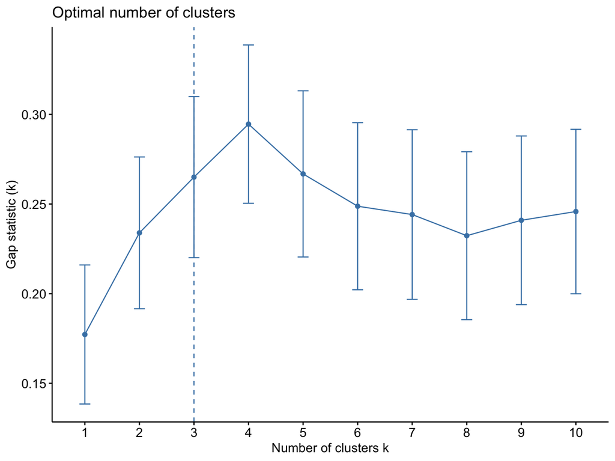

```r
set.seed(100)

gap_stat <- clusGap(USArrests.scale, FUN = hcut, nstart = 25, K.max = 10, B = 50, mc_metric = "euclidean")
fviz_gap_stat(gap_stat)
```

```r
# Create Dissimilarity matrix
diss.matrix <- dist(USArrests.scale, method = "euclidean")

# Hierarchical clustering using Single Linkage
hc1 <- hclust(diss.matrix, method = "single" )

groups.1<-cutree(hc1,4)
aggregate(USArrests.scale,list(groups.1),mean)
```

```
##   Group.1      Murder    Assault    UrbanPop      Rape
## 1       1 -0.07710374 -0.1155488 -0.05683055 -0.181203
## 2       2  0.50786248  1.1068225 -1.21176419  2.484203
## 3       3  0.64561903  1.1188219  1.41349461  2.356085
## 4       4  1.74767144  1.9707777  0.99898006  1.138967
```

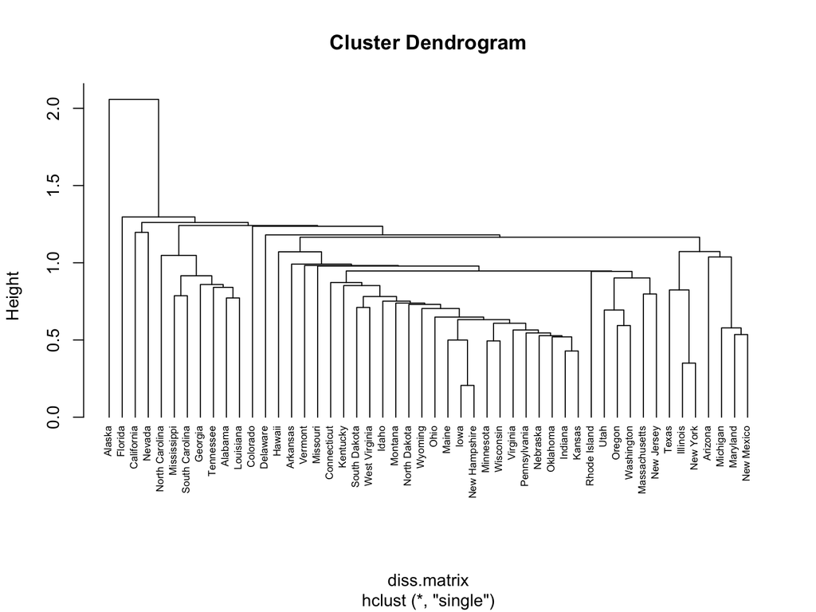

```r
# Plot the obtained dendrogram using Single
plot(hc1, cex = 0.6, hang = -1)
```

```r
# Hierarchical clustering using Complete Linkage
hc2 <- hclust(diss.matrix, method = "complete" )

groups.2 <-cutree(hc2,4)
aggregate(USArrests.scale,list(groups.2),mean)
```

```
##   Group.1     Murder    Assault   UrbanPop       Rape
## 1       1  1.4463290  0.9838289 -0.8317925  0.3529110
## 2       2  0.7499801  1.1199128  0.9361748  1.2156432
## 3       3 -0.4400338 -0.4353831  0.3607592 -0.2830385
## 4       4 -1.0579703 -1.1046626 -1.1219527 -1.0251554
```

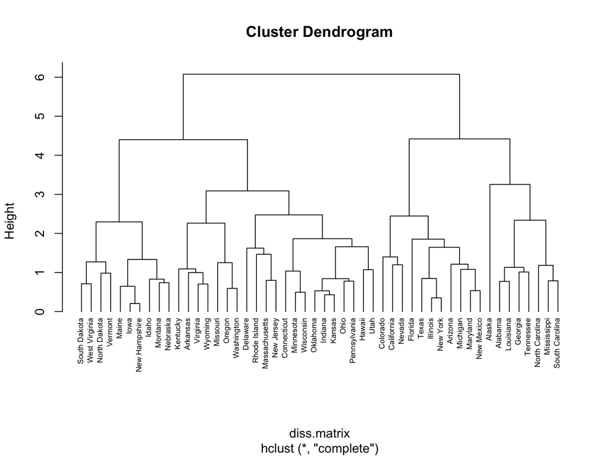

```r
# Plot the obtained dendrogram using Complete
plot(hc2, cex = 0.6, hang = -1)
```

```r
# Hierarchical clustering using Average Linkage
hc3 <- hclust(diss.matrix, method = "average" )

groups.3<-cutree(hc3,4)
aggregate(USArrests.scale,list(groups.3),mean)
```

```
##   Group.1     Murder    Assault   UrbanPop        Rape
## 1       1  1.5803956  0.9662584 -0.7775109  0.04844071
## 2       2  0.5078625  1.1068225 -1.2117642  2.48420294
## 3       3  0.7106707  1.0338263  0.8838371  1.17633437
## 4       4 -0.6699560 -0.6758849 -0.1317235 -0.56464334
```

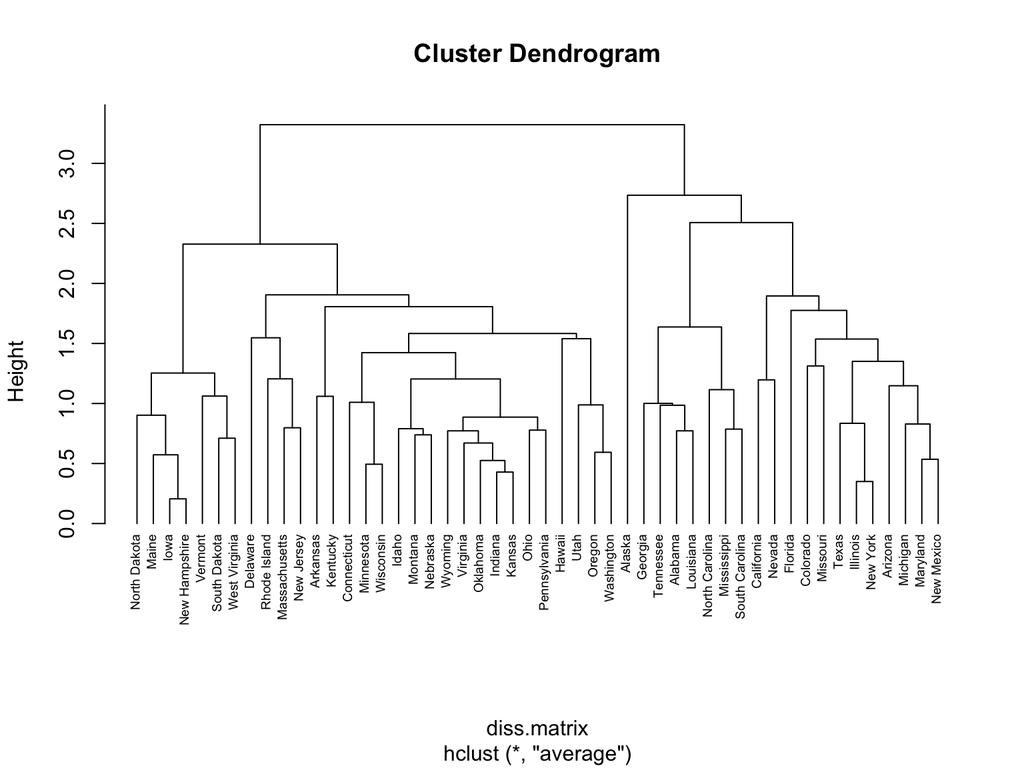

```r
# Plot the obtained dendrogram using Average
plot(hc3, cex = 0.6, hang = -1)
```

The optimal number of clusters to use using a clear, data driven strategy is three cluster for each of the different types of compositions.

### Question 5

One question that can be addressed in 2020, would be to see if the change in UrbanPop can predict if there is more crime: Murder, Assualt, and Rape across the different states.